# Lecture 17 Causal Diagram Practice

Nick Huntington-Klein

March 3, 2019

## Recap

- To make a diagram:
- List all the relevant variables
- Combine identical variables, eliminate unimportant ones
- Draw arrows to indicate what you think causes what
- (See if the model implies that any relationships SHOULDN’T exist and test that)
- Think carefully!

## Recap

- If we’re interested in the effect of `X` on `Y`:
- Write the list of all paths from `X` to `Y`
- Figure out which are front-door paths (going from `X` to `Y`)
- and which are back-door paths (other ways)
- Then figure out what set of variables need to be controlled/adjusted for to close those back doors

## Testing Relationships

- Just a little more detail on this “testing relationships” thing
- Our use of front-door and back-door paths means that we can look at *any two variables* in our diagram and say “hmm, if I control for A, B, and C, then that closes all front and back door paths between D and E”
- So, if we control for A, B, and C, then D and E should be unrelated!
- If `cor(D,E)` controlling for A, B, C is big, our diagram is probably wrong!

## Testing Relationships

- What are some relationships we can test?

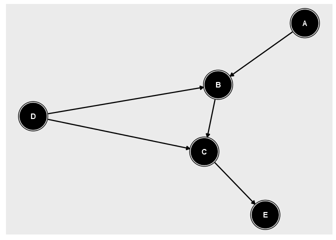

## Testing Relationships

- We should get no relationship between: A and E controlling for C, B and E controlling for C, D and E controlling for C
- (also D and A controlling for nothing, but we haven’t gotten to why that one works yet, and A and C controlling for B and D, but we haven’t covered why we need D there)
- We’ll be looking out for opportunities to test our models as we move forward! (note: dagitty will give us a list of what we can test!)

## Today

- In groups, read [the assigned article](https://www.nytimes.com/2019/01/21/upshot/stuck-and-stressed-the-health-costs-of-traffic.html)
- Pick one of the causal claims in the article (there are a lot!)
- [Hint: words like “improve” “affect” “reduces”, ask if you’re not sure]
- Draw a diagram to investigate that causal question
- Determine what needs to be controlled for to identify that effect
- If there’s a linked study to explain the claim, try to look at it and see if they use the appropriate controls
- Extra time? Do another claim

## Causal Inference in the News

- Not long: 1-2 pages single-spaced plus diagram.
- Find a news article that makes a causal claim (like the one we just did, but not that one) and interpret that claim by drawing an appropriate diagram in dagitty
- Doesn’t necessarily need to be a claim backed by a study or evidence, but it makes the assignment easier if it is
- Justify your diagram (both your choice of variables and your arrows)
- Explain how you would identify the causal claim, and discuss whether you think the article did so or not.